# Efek Parameter pada Distribusi Peluang

Tim Modul 60

2/13/2021

```r
library(ggplot2)
library(gridExtra)
library(dplyr)
```

**Catatan : Kodingan ini untuk memenuhi tugas simdat, kemungkinan banyak kesalahan. Mohon dimaklumi**

# Normal Distribution

## Density Function

### Mean constant, sd berubah

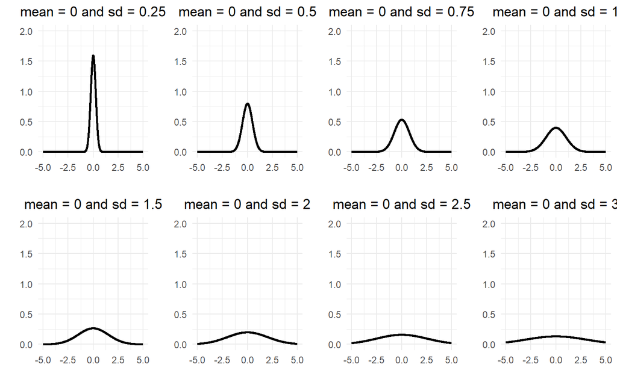

```r
normalDistribution <- function(mean = 0, sd = 1){
      judul <- paste("mean =", mean, "and sd =", sd)
      ggplot(data = data.frame(x = c(mean - 5, mean + 5)), aes(x)) +
            stat_function(fun = dnorm, n = 1000, args = list(mean = mean, sd = sd),
                          size = 1) +
            labs(x = "",
                 y = "",
                 title = judul) +
            scale_y_continuous(limits = c(0, 2)) +
            theme_minimal() +
            theme(plot.title = element_text(hjust = 0.5))
}

a <- normalDistribution(mean = 0, sd = 0.25)
b <- normalDistribution(mean = 0, sd = 0.5)
c <- normalDistribution(mean = 0, sd = 0.75)
d <- normalDistribution(mean = 0, sd = 1)
e <- normalDistribution(mean = 0, sd = 1.5)
f <- normalDistribution(mean = 0, sd = 2)
g <- normalDistribution(mean = 0, sd = 2.5)
h <- normalDistribution(mean = 0, sd = 3)
grid.arrange(a, b, c, d, e, f, g, h, nrow = 2)
```

### Mean berubah, sd konstant

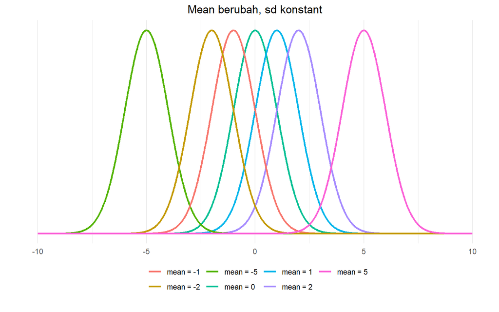

```r
ggplot(data = data.frame(x = c(-10, 10)), aes(x)) +
            stat_function(fun = dnorm, n = 1000, args = list(mean = 0, sd = 1),
                          size = 1, aes(color = "mean = 0")) +
            stat_function(fun = dnorm, n = 1000, args = list(mean = 1, sd = 1),
                          size = 1, aes(color = "mean = 1")) +
            stat_function(fun = dnorm, n = 1000, args = list(mean = 2, sd = 1),
                          size = 1, aes(color = "mean = 2")) +
            stat_function(fun = dnorm, n = 1000, args = list(mean = -5, sd = 1),
                          size = 1, aes(color = "mean = -5")) +
            stat_function(fun = dnorm, n = 1000, args = list(mean = -1, sd = 1),
                          size = 1, aes(color = "mean = -1")) +
            stat_function(fun = dnorm, n = 1000, args = list(mean = -2, sd = 1),
                          size = 1, aes(color = "mean = -2")) +
            stat_function(fun = dnorm, n = 1000, args = list(mean = 5, sd = 1),
                          size = 1, aes(color = "mean = 5")) +
            labs(x = "",
                 y = "",
                 title = "Mean berubah, sd konstant") +
            scale_y_continuous(breaks = NULL) +
            theme_minimal() +
            theme(plot.title = element_text(hjust = 0.5),
                  legend.position = "bottom",
                  legend.title = element_blank(),
                  legend.box.margin = margin(-20, 0, 10, 0))
```

## Random Data

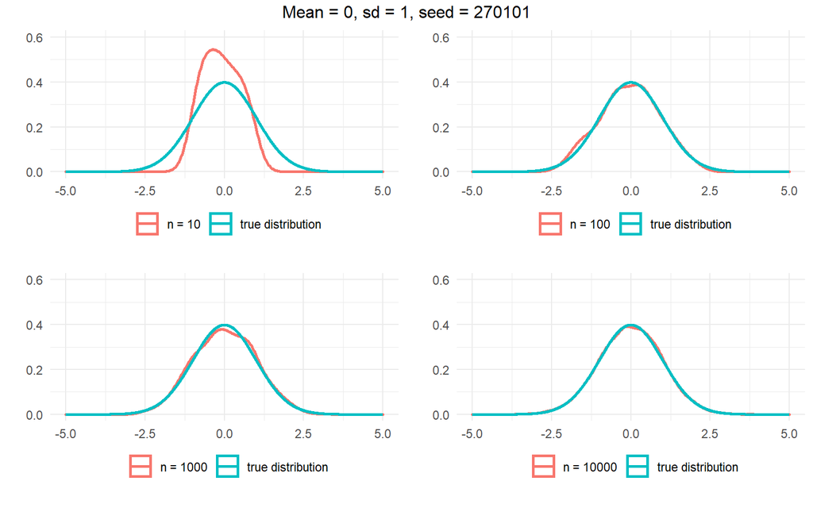

```r
normalDistribution2 <- function(n, seed, mean = 0, sd = 1, yaxis = 0.6){
      set.seed(seed)
      data <- data.frame(x = rnorm(n = n, mean = mean, sd = sd))
      ggplot() +
            geom_density(data = data,
                         aes(x, color = paste("n =", n)), size = 1) +
            stat_function(fun = dnorm, n = 1000, args = list(mean = mean, sd = sd),
                                size = 1, aes(color = "true distribution")) +
            scale_x_continuous(limits = c(mean - 5, mean + 5)) +
            scale_y_continuous(limits = c(0, yaxis)) +
            labs(x = "", y = "") +
            theme_minimal() +
            theme(legend.position = "bottom",
                  legend.title = element_blank(),
                  legend.box.margin = margin(-20, 0, 10, 0))
}

p1 <- normalDistribution2(n = 10, seed = 270101, mean = 0, sd = 1)
p2 <- normalDistribution2(n = 100, seed = 270101, mean = 0, sd = 1)
p3 <- normalDistribution2(n = 1000, seed = 270101, mean = 0, sd = 1)
p4 <- normalDistribution2(n = 10000, seed = 270101, mean = 0, sd = 1)

grid.arrange(p1, p2, p3, p4, nrow = 2, top = "Mean = 0, sd = 1, seed = 270101")
```

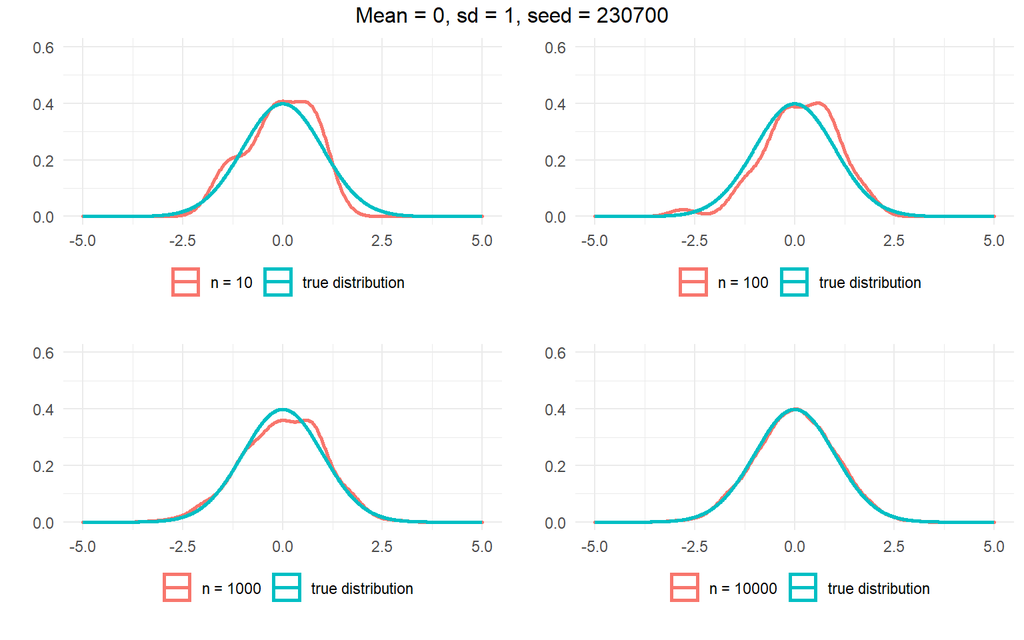

```r
p1 <- normalDistribution2(n = 10, seed = 230700, mean = 0, sd = 1)
p2 <- normalDistribution2(n = 100, seed = 230700, mean = 0, sd = 1)
p3 <- normalDistribution2(n = 1000, seed = 230700, mean = 0, sd = 1)
p4 <- normalDistribution2(n = 10000, seed = 230700, mean = 0, sd = 1)

grid.arrange(p1, p2, p3, p4, nrow = 2, top = "Mean = 0, sd = 1, seed = 230700")
```

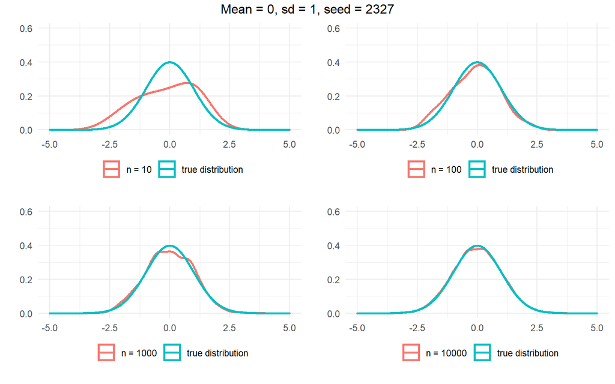

```r
p1 <- normalDistribution2(n = 10, seed = 2327, mean = 0, sd = 1)
p2 <- normalDistribution2(n = 100, seed = 2327, mean = 0, sd = 1)
p3 <- normalDistribution2(n = 1000, seed = 2327, mean = 0, sd = 1)
p4 <- normalDistribution2(n = 10000, seed = 2327, mean = 0, sd = 1)

grid.arrange(p1, p2, p3, p4, nrow = 2, top = "Mean = 0, sd = 1, seed = 2327")
```

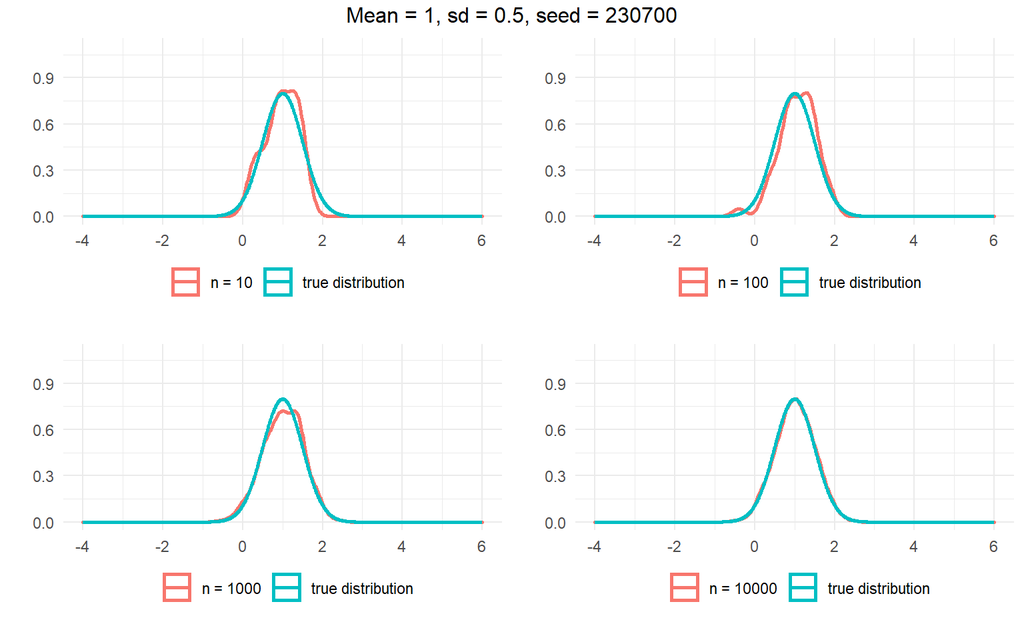

```r
p1 <- normalDistribution2(n = 10, seed = 230700, mean = 1, sd = 0.5, yaxis = 1.1)
p2 <- normalDistribution2(n = 100, seed = 230700, mean = 1, sd = 0.5, yaxis = 1.1)
p3 <- normalDistribution2(n = 1000, seed = 230700, mean = 1, sd = 0.5, yaxis = 1.1)
p4 <- normalDistribution2(n = 10000, seed = 230700, mean = 1, sd = 0.5, yaxis = 1.1)

grid.arrange(p1, p2, p3, p4, nrow = 2, top = "Mean = 1, sd = 0.5, seed = 230700")
```

## Kesimpulan

Dari beberapa plot diatas dapat disimpulkan

1. Nilai `sd` berpengaruh pada keruncingan kurva, semakin kecil nilainya maka akan semakin runcing dan begitu sebaliknya.
2. Nilai `mean` berpengaruh pada letak pusat dari kurva. Perubahan nilai `mean` akan merubah letak kurva di sumbu x
3. Dari beberapa percobaan dengan membangkitkan data random, terlihat bahwa untuk `n <= 100`, data yabg dibangkitkan masih agak berbeda dengan distribusi aslinya. Untuk `n` sekitar ribuan masih tergantung hasil random datanya. Sementara itu untuk `n` yang sangat besar, `n >= 10000`, hasil randomnya sangat mendekati dengan distribusi aslinya.

# Chi Square Distribution

## Density Function

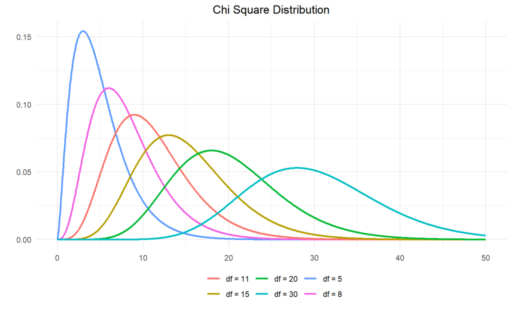

```r
ggplot(data = data.frame(x = c(0, 50)), aes(x)) +
            stat_function(fun = dchisq, n = 1000, args = list(df = 5),
                          size = 1, aes(color = "df = 5")) +
            stat_function(fun = dchisq, n = 1000, args = list(df = 8),
                          size = 1, aes(color = "df = 8")) +
            stat_function(fun = dchisq, n = 1000, args = list(df = 11),
                          size = 1, aes(color = "df = 11")) +
            stat_function(fun = dchisq, n = 1000, args = list(df = 15),
                          size = 1, aes(color = "df = 15")) +
            stat_function(fun = dchisq, n = 1000, args = list(df = 20),
                          size = 1, aes(color = "df = 20")) +
            stat_function(fun = dchisq, n = 1000, args = list(df = 30),
                          size = 1, aes(color = "df = 30")) +
            labs(x = "",
                 y = "",
                 title = "Chi Square Distribution") +
            theme_minimal() +
            theme(plot.title = element_text(hjust = 0.5),
                  legend.position = "bottom",
                  legend.title = element_blank(),
                  legend.box.margin = margin(-20, 0, 10, 0))
```

## Random Data

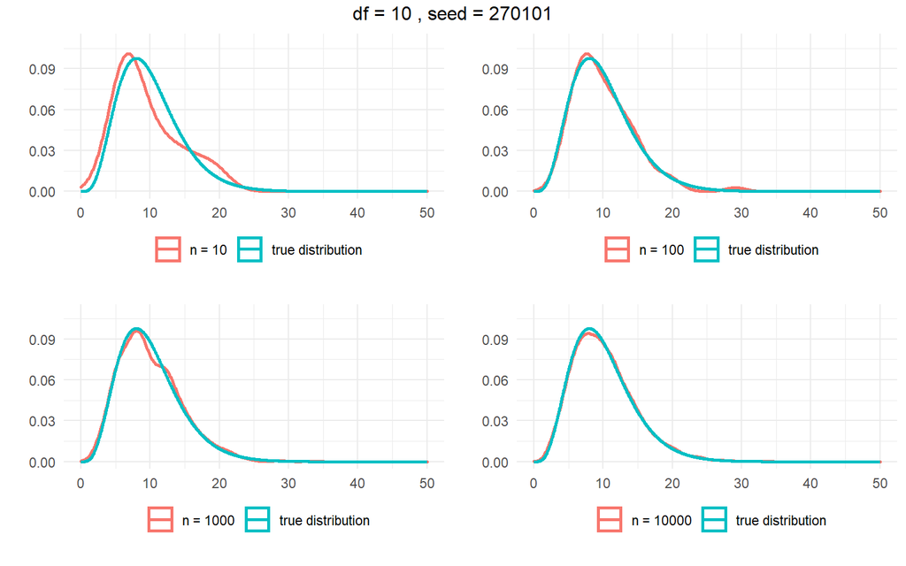

```r
chiSquare <- function(n, seed, df, yaxis = 0.11, xaxis = 50){
      set.seed(seed)
      data <- data.frame(x = rchisq(n = n, df = df))
      ggplot() +
            geom_density(data = data,
                         aes(x, color = paste("n =", n)), size = 1) +
            stat_function(fun = dchisq, n = 1000, args = list(df = df),
                                size = 1, aes(color = "true distribution")) +
            scale_x_continuous(limits = c(0, xaxis)) +
            scale_y_continuous(limits = c(0, yaxis)) +
            labs(x = "", y = "") +
            theme_minimal() +
            theme(legend.position = "bottom",
                  legend.title = element_blank(),
                  legend.box.margin = margin(-20, 0, 10, 0))
}

seed <- 270101
df <- 10
p1 <- chiSquare(n = 10, seed = seed, df = df)
p2 <- chiSquare(n = 100, seed = seed, df = df)
p3 <- chiSquare(n = 1000, seed = seed, df = df)
p4 <- chiSquare(n = 10000, seed = seed, df = df)

grid.arrange(p1, p2, p3, p4, nrow = 2, top = paste("df =", df, ", seed =", seed))
```

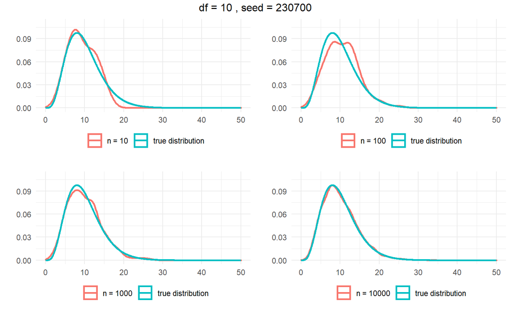

```r
seed <- 230700
df <- 10
p1 <- chiSquare(n = 10, seed = seed, df = df)
p2 <- chiSquare(n = 100, seed = seed, df = df)
p3 <- chiSquare(n = 1000, seed = seed, df = df)
p4 <- chiSquare(n = 10000, seed = seed, df = df)

grid.arrange(p1, p2, p3, p4, nrow = 2, top = paste("df =", df, ", seed =", seed))
```

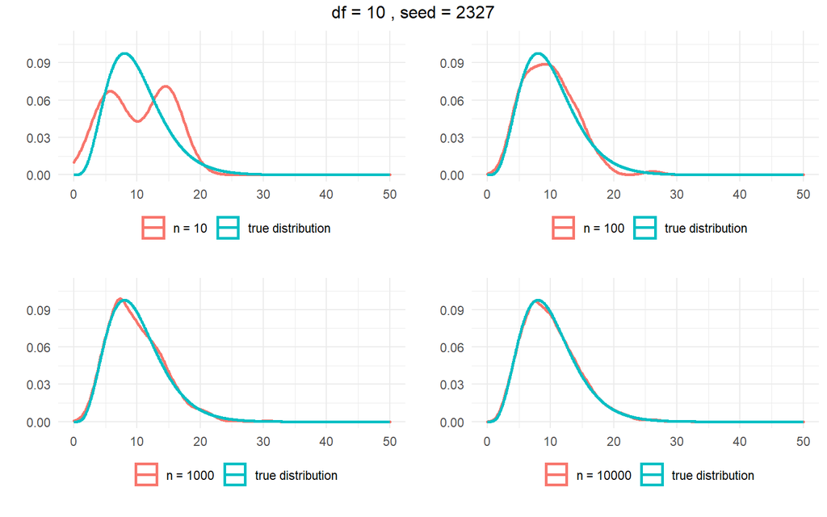

```r
seed <- 2327
df <- 10
p1 <- chiSquare(n = 10, seed = seed, df = df)
p2 <- chiSquare(n = 100, seed = seed, df = df)
p3 <- chiSquare(n = 1000, seed = seed, df = df)
p4 <- chiSquare(n = 10000, seed = seed, df = df)

grid.arrange(p1, p2, p3, p4, nrow = 2, top = paste("df =", df, ", seed =", seed))
```

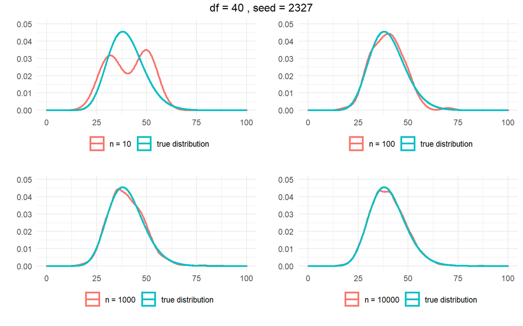

```r
seed <- 2327
df <- 40
yaxis <- 0.05
xaxis <- 100
p1 <- chiSquare(n = 10, seed = seed, df = df, yaxis = yaxis, xaxis = xaxis)
p2 <- chiSquare(n = 100, seed = seed, df = df, yaxis = yaxis, xaxis = xaxis)
p3 <- chiSquare(n = 1000, seed = seed, df = df, yaxis = yaxis, xaxis = xaxis)
p4 <- chiSquare(n = 10000, seed = seed, df = df, yaxis = yaxis, xaxis = xaxis)

grid.arrange(p1, p2, p3, p4, nrow = 2, top = paste("df =", df, ", seed =", seed))
```

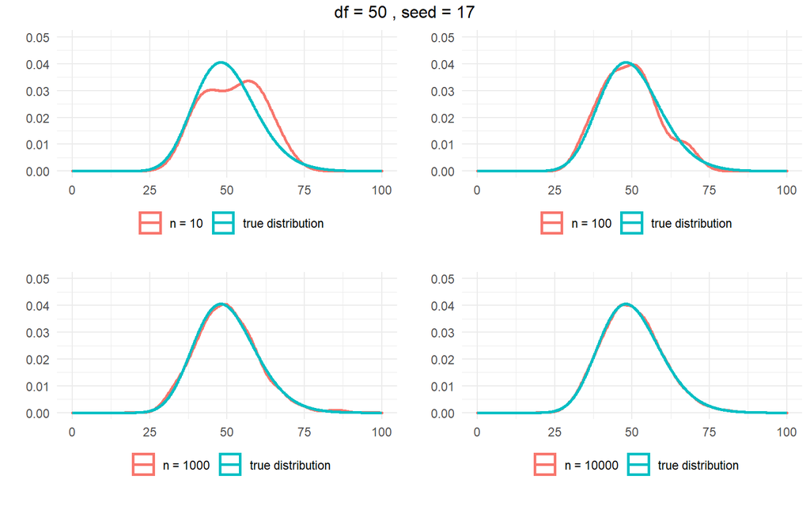

```r
seed <- 17
df <- 50
yaxis <- 0.05
xaxis <- 100
p1 <- chiSquare(n = 10, seed = seed, df = df, yaxis = yaxis, xaxis = xaxis)
p2 <- chiSquare(n = 100, seed = seed, df = df, yaxis = yaxis, xaxis = xaxis)
p3 <- chiSquare(n = 1000, seed = seed, df = df, yaxis = yaxis, xaxis = xaxis)
p4 <- chiSquare(n = 10000, seed = seed, df = df, yaxis = yaxis, xaxis = xaxis)

grid.arrange(p1, p2, p3, p4, nrow = 2, top = paste("df =", df, ", seed =", seed))
```

## Kesimpulan

Dari beberapa plot diatas diperoleh bahwa

1. Nilai `degree of freedom` berpengaruh pada kurva, ketika nilainya kecil maka kurva akan menceng kanan, dan ketika semakin besar, `df > 30`, kurvanya akan mirip dengan distribusi.
2. Berdasarkan random data, ketika `n` sangat kecil kurva dari hasil random sangat berbeda jauh dengan curva chi-square. Dari percaobaan diatas curva akan mengikuti yang sebenarnya ketika `n > 1000`.

# Student t Distribution

## Density FUnction

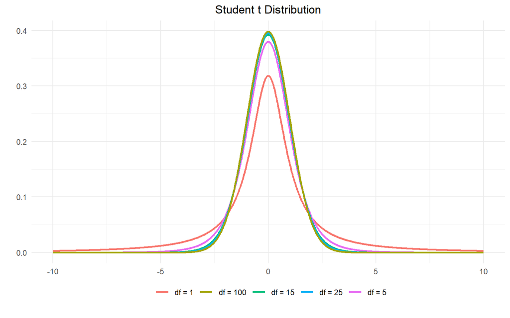

```r
ggplot(data = data.frame(x = c(-10, 10)), aes(x)) +
            stat_function(fun = dt, n = 1000, args = list(df = 1),
                          size = 1, aes(color = "df = 1")) +
            stat_function(fun = dt, n = 1000, args = list(df = 5),
                          size = 1, aes(color = "df = 5")) +
            stat_function(fun = dt, n = 1000, args = list(df = 15),
                          size = 1, aes(color = "df = 15")) +
            stat_function(fun = dt, n = 1000, args = list(df = 25),
                          size = 1, aes(color = "df = 25")) +
            stat_function(fun = dt, n = 1000, args = list(df = 100),
                          size = 1, aes(color = "df = 100")) +
            labs(x = "",
                 y = "",
                 title = "Student t Distribution") +
            theme_minimal() +
            theme(plot.title = element_text(hjust = 0.5),
                  legend.position = "bottom",
                  legend.title = element_blank(),
                  legend.box.margin = margin(-20, 0, 10, 0))
```

## Random Data

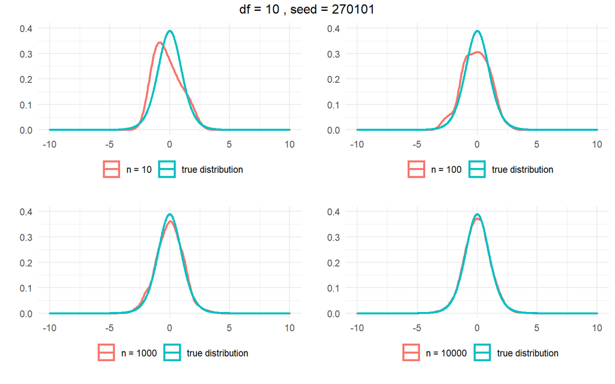

```r
tDistribution <- function(n, seed, df, yaxis = 0.4){
      set.seed(seed)
      data <- data.frame(x = rt(n = n, df = df))
      ggplot() +
            geom_density(data = data,
                         aes(x, color = paste("n =", n)), size = 1) +
            stat_function(fun = dt, n = 1000, args = list(df = df),
                                size = 1, aes(color = "true distribution")) +
            scale_x_continuous(limits = c(-10, 10)) +
            scale_y_continuous(limits = c(0, yaxis)) +
            labs(x = "", y = "") +
            theme_minimal() +
            theme(legend.position = "bottom",
                  legend.title = element_blank(),
                  legend.box.margin = margin(-20, 0, 10, 0))
}

seed <- 270101
df <- 10
p1 <- tDistribution(n = 10, seed = seed, df = df)
p2 <- tDistribution(n = 100, seed = seed, df = df)
p3 <- tDistribution(n = 1000, seed = seed, df = df)
p4 <- tDistribution(n = 10000, seed = seed, df = df)

grid.arrange(p1, p2, p3, p4, nrow = 2, top = paste("df =", df, ", seed =", seed))
```

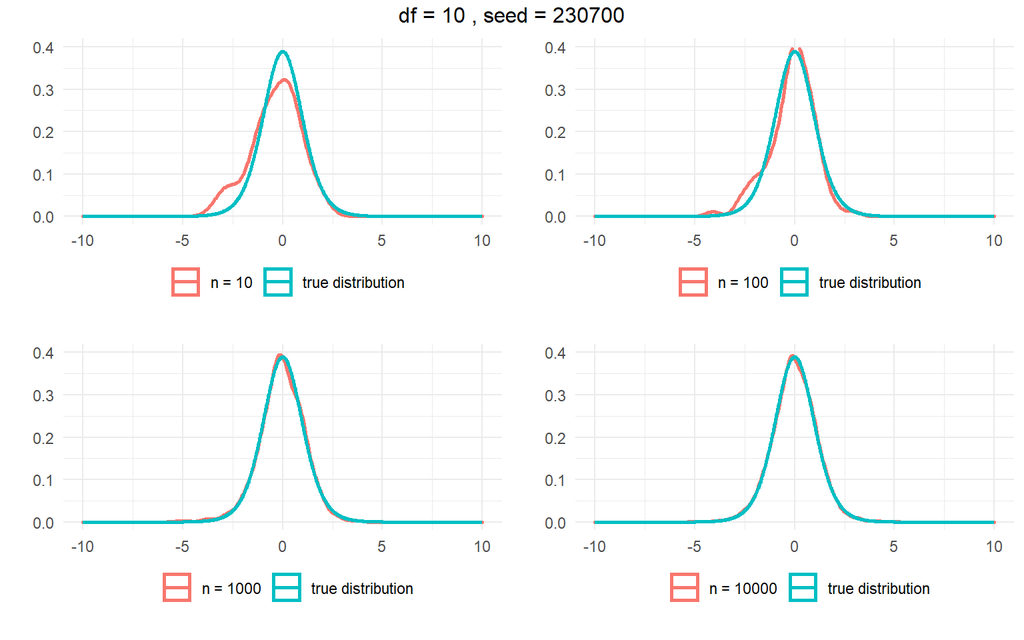

```r
seed <- 230700
df <- 10
p1 <- tDistribution(n = 10, seed = seed, df = df)
p2 <- tDistribution(n = 100, seed = seed, df = df)
p3 <- tDistribution(n = 1000, seed = seed, df = df)
p4 <- tDistribution(n = 10000, seed = seed, df = df)

grid.arrange(p1, p2, p3, p4, nrow = 2, top = paste("df =", df, ", seed =", seed))
```

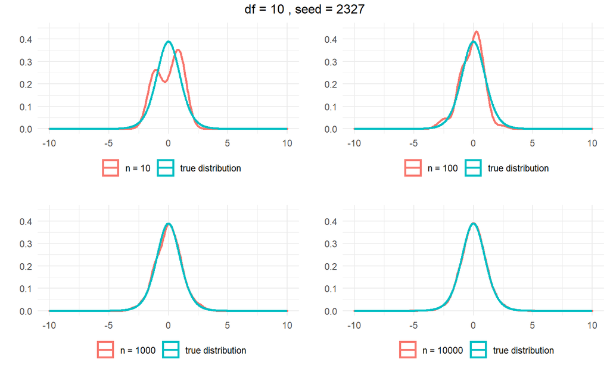

```r
seed <- 2327
df <- 10
yaxis <- 0.45
p1 <- tDistribution(n = 10, seed = seed, df = df, yaxis = yaxis)
p2 <- tDistribution(n = 100, seed = seed, df = df, yaxis = yaxis)
p3 <- tDistribution(n = 1000, seed = seed, df = df, yaxis = yaxis)
p4 <- tDistribution(n = 10000, seed = seed, df = df, yaxis = yaxis)

grid.arrange(p1, p2, p3, p4, nrow = 2, top = paste("df =", df, ", seed =", seed))
```

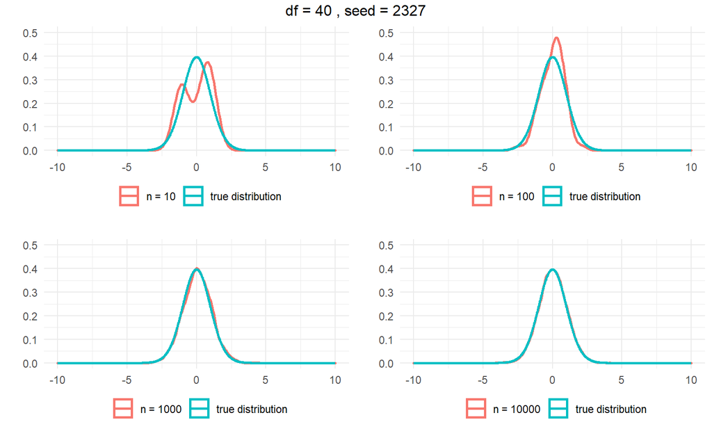

```r
seed <- 2327
df <- 40
yaxis <- 0.5
p1 <- tDistribution(n = 10, seed = seed, df = df, yaxis = yaxis)
p2 <- tDistribution(n = 100, seed = seed, df = df, yaxis = yaxis)
p3 <- tDistribution(n = 1000, seed = seed, df = df, yaxis = yaxis)
p4 <- tDistribution(n = 10000, seed = seed, df = df, yaxis = yaxis)

grid.arrange(p1, p2, p3, p4, nrow = 2, top = paste("df =", df, ", seed =", seed))
```

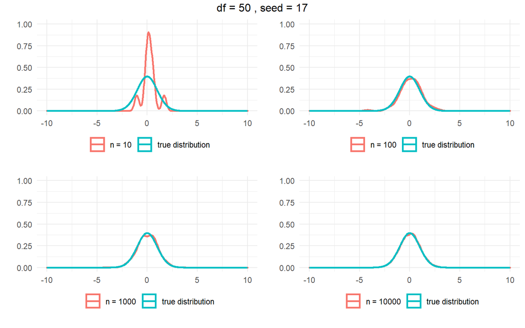

```r
seed <- 17
df <- 50
yaxis <- 1

p1 <- tDistribution(n = 10, seed = seed, df = df, yaxis = yaxis)
p2 <- tDistribution(n = 100, seed = seed, df = df, yaxis = yaxis)
p3 <- tDistribution(n = 1000, seed = seed, df = df, yaxis = yaxis)
p4 <- tDistribution(n = 10000, seed = seed, df = df, yaxis = yaxis)

grid.arrange(p1, p2, p3, p4, nrow = 2, top = paste("df =", df, ", seed =", seed))
```

## Kesimpulan

Dari beberapa plot diatas diperoleh bahwa

1. Distribusi $t$ selalu berpusat di titik 0
2. Distribusi $t$ dipengaruhi oleh nilai `degree of freedom`. Nilai ini berpengaruh pada keruncingan kurva
3. Ketika nilai `df` masih kecil, perubahannya akan terlihat jelas, akan tetapi semikin besar nilai `df` perubahannya akan tidak terlalu berpengaruh. Hal tersebut terlihat pada kurva dengan `df = 25` sangat berhimpitan dengan `df = 100` akan tetapi untuk `df = 1` sangat berbeda ketika `df = 5`
4. Ketikan `df` semakin besar maka akan mendekati distribusi normal dengan `mean = 0` dan `sd = 1`
5. Untuk data random, ketika `n > 1000`, data yang dibangkitkan semakin mirip dengan distribusi aslinya.

# F Distribution

## Density Function

### df1 konstan dan df2 berubah

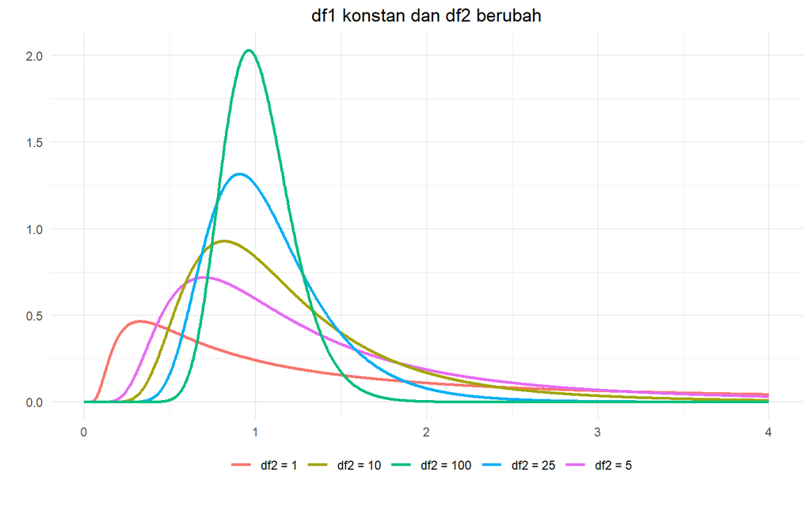

```r
ggplot(data = data.frame(x = c(0, 4)), aes(x)) +
            stat_function(fun = stats::df, n = 1000, args = list(df1 = 100, df2 = 1),
                          size = 1, aes(color = "df2 = 1")) +
            stat_function(fun = stats::df, n = 1000, args = list(df1 = 100, df2 = 5),
                          size = 1, aes(color = "df2 = 5")) +
            stat_function(fun = stats::df, n = 1000, args = list(df1 = 100, df2 = 10),
                          size = 1, aes(color = "df2 = 10")) +
            stat_function(fun = stats::df, n = 1000, args = list(df1 = 100, df2 = 25),
                          size = 1, aes(color = "df2 = 25")) +
            stat_function(fun = stats::df, n = 1000, args = list(df1 = 100, df2 = 100),
                          size = 1, aes(color = "df2 = 100")) +
            labs(x = "",
                 y = "",
                 title = "df1 konstan dan df2 berubah") +
            theme_minimal() +
            theme(plot.title = element_text(hjust = 0.5),
                  legend.position = "bottom",
                  legend.title = element_blank(),
                  legend.box.margin = margin(-20, 0, 10, 0))
```

### df1 berubah dan df2 konstant

[figure not shown]

```r
ggplot(data = data.frame(x = c(0, 4)), aes(x)) +
            stat_function(fun = stats::df, n = 1000, args = list(df1 = 3, df2 = 100),
                          size = 1, aes(color = "df1 = 1")) +
            stat_function(fun = stats::df, n = 1000, args = list(df1 = 5, df2 = 100),
                          size = 1, aes(color = "df1 = 5")) +
            stat_function(fun = stats::df, n = 1000, args = list(df1 = 10, df2 = 100),
                          size = 1, aes(color = "df1 = 10")) +
            stat_function(fun = stats::df, n = 1000, args = list(df1 = 25, df2 = 100),
                          size = 1, aes(color = "df1 = 25")) +
            stat_function(fun = stats::df, n = 1000, args = list(df1 = 100, df2 = 100),
                          size = 1, aes(color = "df1 = 100")) +
            labs(x = "",
                 y = "",
                 title = "df1 berubah dan df2 konstan") +
            theme_minimal() +
            theme(plot.title = element_text(hjust = 0.5),
                  legend.position = "bottom",
                  legend.title = element_blank(),
                  legend.box.margin = margin(-20, 0, 10, 0))
```

## Data Random

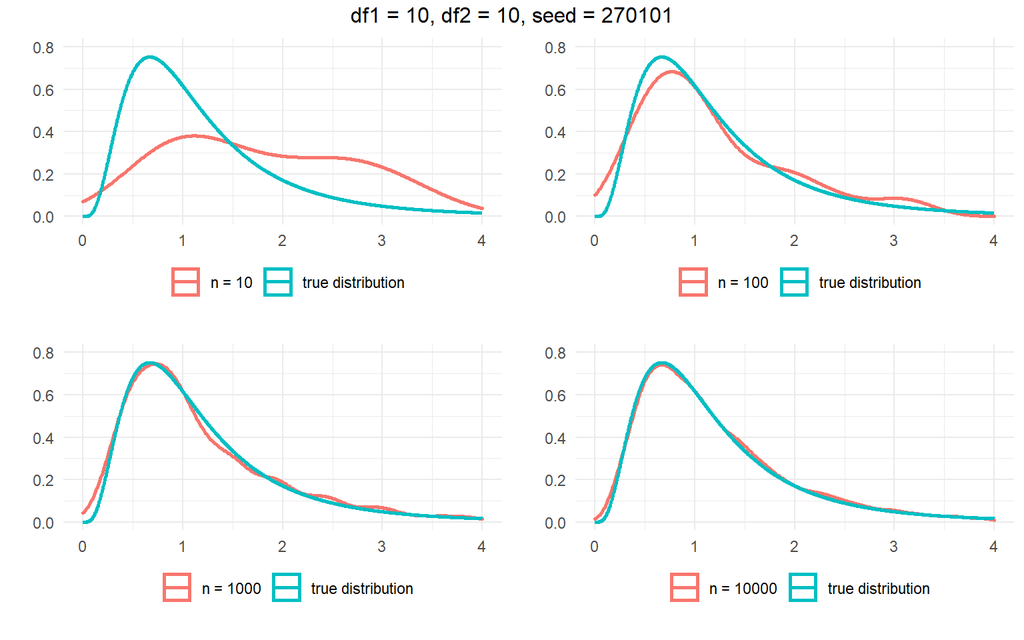

```r
fDistribution <- function(n, seed, df1, df2, yaxis = 0.8){
      set.seed(seed)
      data <- data.frame(x = rf(n = n, df1 = df1, df2 = df2))
      ggplot() +
            geom_density(data = data,
                         aes(x, color = paste("n =", n)), size = 1) +
            stat_function(fun = stats::df, n = 1000, args = list(df1 = df1, df2 = df2),
                                size = 1, aes(color = "true distribution")) +
            scale_x_continuous(limits = c(0, 4)) +
            scale_y_continuous(limits = c(0, yaxis)) +
            labs(x = "", y = "") +
            theme_minimal() +
            theme(legend.position = "bottom",
                  legend.title = element_blank(),
                  legend.box.margin = margin(-20, 0, 10, 0))
}

seed <- 270101
df1 <- 10
df2 <- 10
p1 <- fDistribution(n = 10, seed = seed, df1 = df1, df2 = df2)
p2 <- fDistribution(n = 100, seed = seed, df1 = df1, df2 = df2)
p3 <- fDistribution(n = 1000, seed = seed, df1 = df1, df2 = df2)
p4 <- fDistribution(n = 10000, seed = seed, df1 = df1, df2 = df2)

grid.arrange(p1, p2, p3, p4, nrow = 2, top = "df1 = 10, df2 = 10, seed = 270101")
```

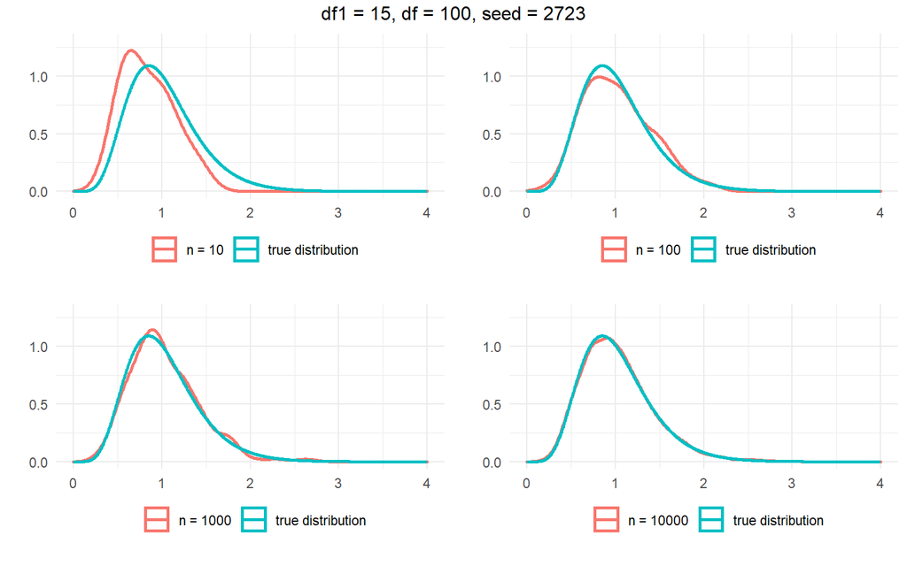

```r
seed <- 2723
df1 <- 15
df2 <- 100
yaxis <- 1.3
p1 <- fDistribution(n = 10, seed = seed, df1 = df1, df2 = df2, yaxis = yaxis)
p2 <- fDistribution(n = 100, seed = seed, df1 = df1, df2 = df2, yaxis = yaxis)
p3 <- fDistribution(n = 1000, seed = seed, df1 = df1, df2 = df2, yaxis = yaxis)
p4 <- fDistribution(n = 10000, seed = seed, df1 = df1, df2 = df2, yaxis = yaxis)

grid.arrange(p1, p2, p3, p4, nrow = 2, top = "df1 = 15, df = 100, seed = 2723")
```

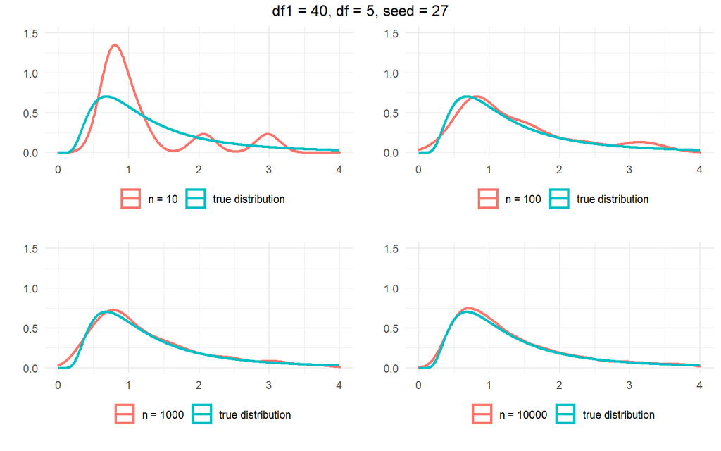

```r
seed <- 27
df1 <- 40
df2 <- 5
yaxis <- 1.5
p1 <- fDistribution(n = 10, seed = seed, df1 = df1, df2 = df2, yaxis = yaxis)
p2 <- fDistribution(n = 100, seed = seed, df1 = df1, df2 = df2, yaxis = yaxis)
p3 <- fDistribution(n = 1000, seed = seed, df1 = df1, df2 = df2, yaxis = yaxis)
p4 <- fDistribution(n = 10000, seed = seed, df1 = df1, df2 = df2, yaxis = yaxis)

grid.arrange(p1, p2, p3, p4, nrow = 2, top = "df1 = 40, df = 5, seed = 27")
```

## Kesimpulan

Dari beberapa plot diatas diperoleh beberapa kesimpulan

1. Distribusi $F$ selalu bernilai positif dan bergantung pada parameter `df1` dan `df2` 2 Parameter `df1` dan `df2` berpengaruh pada keruncingan dan kemencengan data. Ketika `df1` dan `df2` kecil maka kurva akan menceng kanan dan tidak runcing. Seiring bertambahnya `df1` dan `df2` kurva akan semakin runcing dan kemencengan akan semakin berkurang
2. Data beberapa percaobaan terlihat bahwa untuk `n` yang sangat besar $> 10000$ barulah kurvanya sangat mirip dengan distribusi aslinya

# Gamma Distribution

## Density Function

### shape berubah, scale konstant

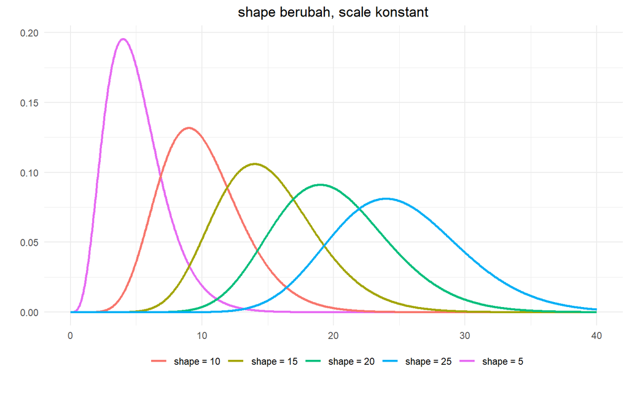

```r
ggplot(data = data.frame(x = c(0, 40)), aes(x)) +
            stat_function(fun = stats::dgamma, n = 1000, args = list(shape = 5, scale = 1),
                          size = 1, aes(color = "shape = 5")) +
            stat_function(fun = stats::dgamma, n = 1000, args = list(shape = 10, scale = 1),
                          size = 1, aes(color = "shape = 10")) +
            stat_function(fun = stats::dgamma, n = 1000, args = list(shape = 15, scale = 1),
                          size = 1, aes(color = "shape = 15")) +
            stat_function(fun = stats::dgamma, n = 1000, args = list(shape = 20, scale = 1),
                          size = 1, aes(color = "shape = 20")) +
            stat_function(fun = stats::dgamma, n = 1000, args = list(shape = 25, scale = 1),
                          size = 1, aes(color = "shape = 25")) +
            labs(x = "",
                 y = "",
                 title = "shape berubah, scale konstant") +
            theme_minimal() +
            theme(plot.title = element_text(hjust = 0.5),
                  legend.position = "bottom",
                  legend.title = element_blank(),
                  legend.box.margin = margin(-20, 0, 10, 0))
```

### shape konstant, scale berubah

[figure not shown]

```r
ggplot(data = data.frame(x = c(0, 40)), aes(x)) +
            stat_function(fun = stats::dgamma, n = 1000, args = list(shape = 10, scale = 0.5),
                          size = 1, aes(color = "scale = 0.5")) +
            stat_function(fun = stats::dgamma, n = 1000, args = list(shape = 10, scale = 0.8),
                          size = 1, aes(color = "scale = 0.8")) +
            stat_function(fun = stats::dgamma, n = 1000, args = list(shape = 10, scale = 1.1),
                          size = 1, aes(color = "scale = 1.1")) +
            stat_function(fun = stats::dgamma, n = 1000, args = list(shape = 10, scale = 1.5),
                          size = 1, aes(color = "scale = 1.5")) +
            stat_function(fun = stats::dgamma, n = 1000, args = list(shape = 10, scale = 2),
                          size = 1, aes(color = "scale = 2")) +
            labs(x = "",
                 y = "",
                 title = "shape berubah, scale konstant") +
            theme_minimal() +
            theme(plot.title = element_text(hjust = 0.5),
                  legend.position = "bottom",
                  legend.title = element_blank(),
                  legend.box.margin = margin(-20, 0, 10, 0))
```

## Random Data

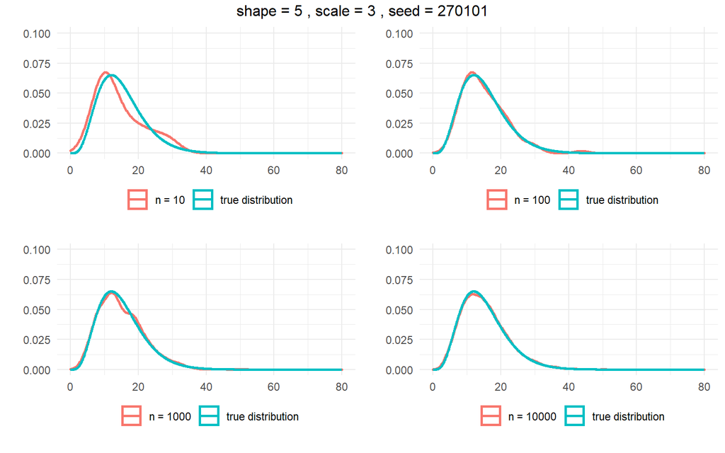

```r
gammaDistribution <- function(n, seed, shape, scale, yaxis = 0.1, xaxis = 80){
      set.seed(seed)
      data <- data.frame(x = rgamma(n = n, shape = shape, scale = scale))
      ggplot() +
            geom_density(data = data,
                         aes(x, color = paste("n =", n)), size = 1) +
            stat_function(fun = dgamma, n = 1000, args = list(shape = shape, scale = scale),
                                size = 1, aes(color = "true distribution")) +
            scale_x_continuous(limits = c(0, xaxis)) +
            scale_y_continuous(limits = c(0, yaxis)) +
            labs(x = "", y = "") +
            theme_minimal() +
            theme(legend.position = "bottom",
                  legend.title = element_blank(),
                  legend.box.margin = margin(-20, 0, 10, 0))
}

seed <- 270101
shape <- 5
scale <- 3
p1 <- gammaDistribution(n = 10, seed = seed, shape = shape, scale = scale)
p2 <- gammaDistribution(n = 100, seed = seed, shape = shape, scale = scale)
p3 <- gammaDistribution(n = 1000, seed = seed, shape = shape, scale = scale)
p4 <- gammaDistribution(n = 10000, seed = seed, shape = shape, scale = scale)

grid.arrange(p1, p2, p3, p4, nrow = 2, top = paste("shape =", shape, ", scale =", scale, ", seed =", seed))
```

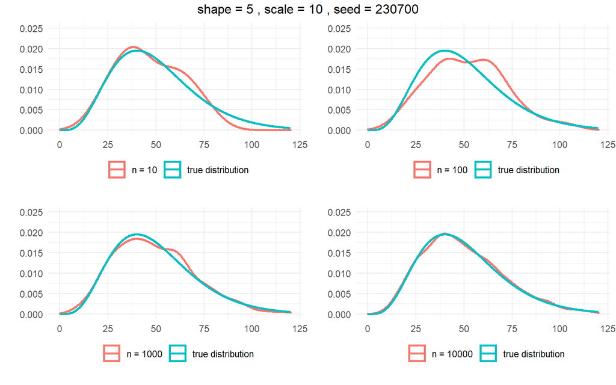

```r
seed <- 230700
shape <- 5
scale <- 10
yaxis <- 0.025
xaxis <- 120
p1 <- gammaDistribution(n = 10, seed = seed, shape = shape, scale = scale, yaxis = yaxis, xaxis = xaxis)
p2 <- gammaDistribution(n = 100, seed = seed, shape = shape, scale = scale, yaxis = yaxis, xaxis = xaxis)
p3 <- gammaDistribution(n = 1000, seed = seed, shape = shape, scale = scale, yaxis = yaxis, xaxis = xaxis)
p4 <- gammaDistribution(n = 10000, seed = seed, shape = shape, scale = scale, yaxis = yaxis, xaxis = xaxis)

grid.arrange(p1, p2, p3, p4, nrow = 2, top = paste("shape =", shape, ", scale =", scale, ", seed =", seed))
```

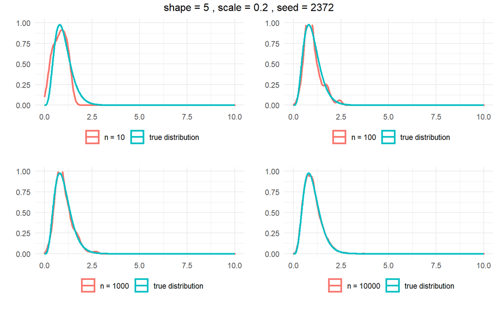

```r
seed <- 2372
shape <- 5
scale <- 0.2
yaxis <- 1
xaxis <- 10
p1 <- gammaDistribution(n = 10, seed = seed, shape = shape, scale = scale, yaxis = yaxis, xaxis = xaxis)
p2 <- gammaDistribution(n = 100, seed = seed, shape = shape, scale = scale, yaxis = yaxis, xaxis = xaxis)
p3 <- gammaDistribution(n = 1000, seed = seed, shape = shape, scale = scale, yaxis = yaxis, xaxis = xaxis)
p4 <- gammaDistribution(n = 10000, seed = seed, shape = shape, scale = scale, yaxis = yaxis, xaxis = xaxis)

grid.arrange(p1, p2, p3, p4, nrow = 2, top = paste("shape =", shape, ", scale =", scale, ", seed =", seed))
```

## Kesimpulan

Dari beberapa plot diatas diperoleh bahwa

# Exponential Distribution

## Density Function

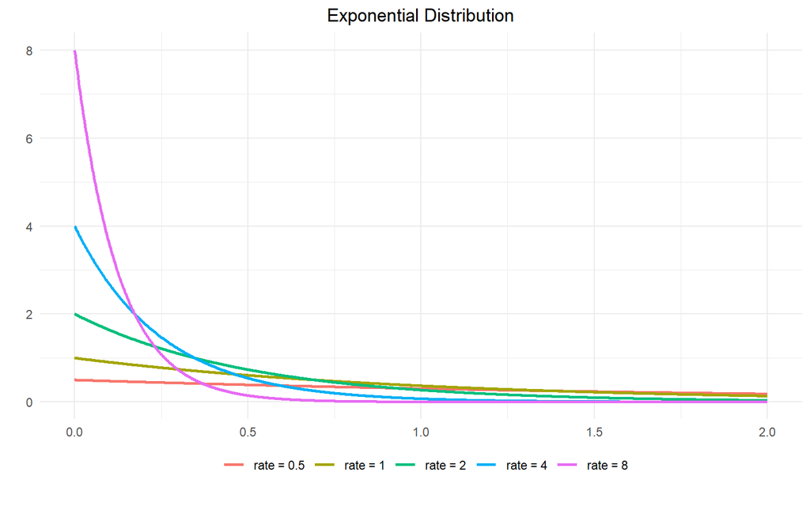

```r
ggplot(data = data.frame(x = c(0, 2)), aes(x)) +
            stat_function(fun = dexp, n = 1000, args = list(rate = 0.5),
                          size = 1, aes(color = "rate = 0.5")) +
            stat_function(fun = dexp, n = 1000, args = list(rate = 1),
                          size = 1, aes(color = "rate = 1")) +
            stat_function(fun = dexp, n = 1000, args = list(rate = 2),
                          size = 1, aes(color = "rate = 2")) +
            stat_function(fun = dexp, n = 1000, args = list(rate = 4),
                          size = 1, aes(color = "rate = 4")) +
            stat_function(fun = dexp, n = 1000, args = list(rate = 8),
                          size = 1, aes(color = "rate = 8")) +
            labs(x = "",
                 y = "",
                 title = "Exponential Distribution") +
            theme_minimal() +
            theme(plot.title = element_text(hjust = 0.5),
                  legend.position = "bottom",
                  legend.title = element_blank(),
                  legend.box.margin = margin(-20, 0, 10, 0))
```